# STAT345 Midterm: Nate Melnikoff

2024-03-26

# STAT345 Mid-Term Project

##### Nate Melnikoff

- I am going to be working for the Milwaukee Bucks on this project. I am comparing the 2013 season to the most recent 2023 season. My goal here is to compare these two seasons and see what we can find in terms of how the game has changed.
- First, we need a court to look at.

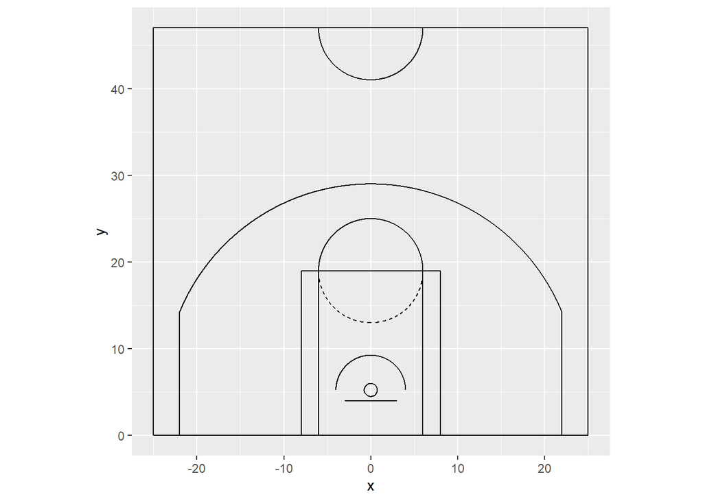

- Now that we have our court, let’s add the Milwaukee Bucks shots from 2013 and 2023 to them.

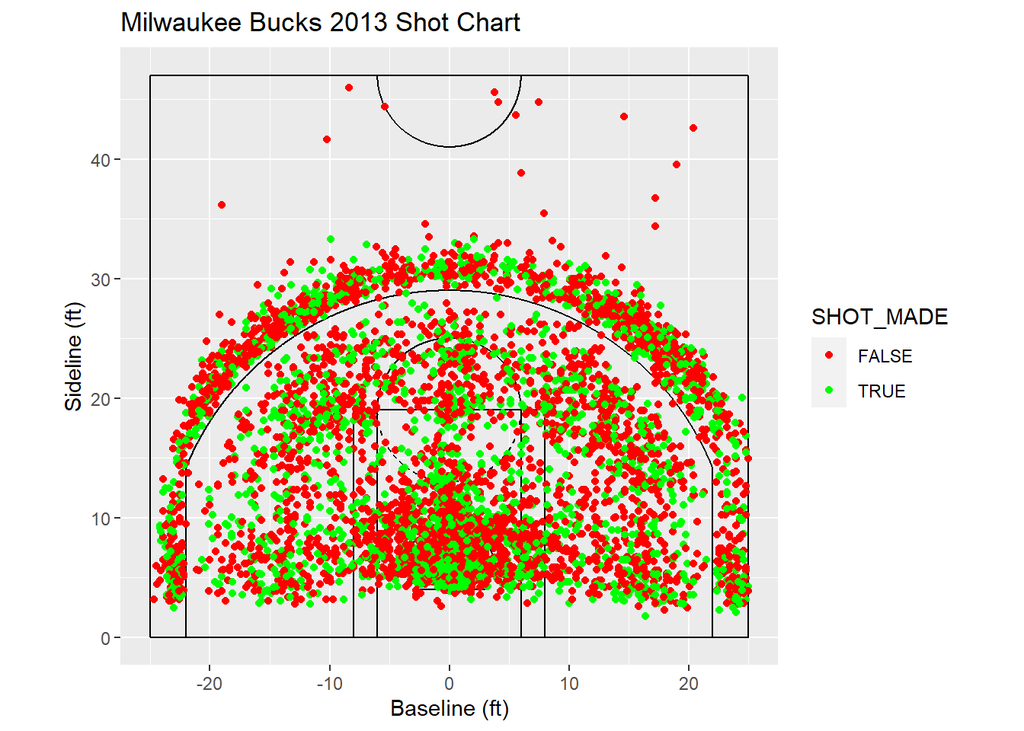

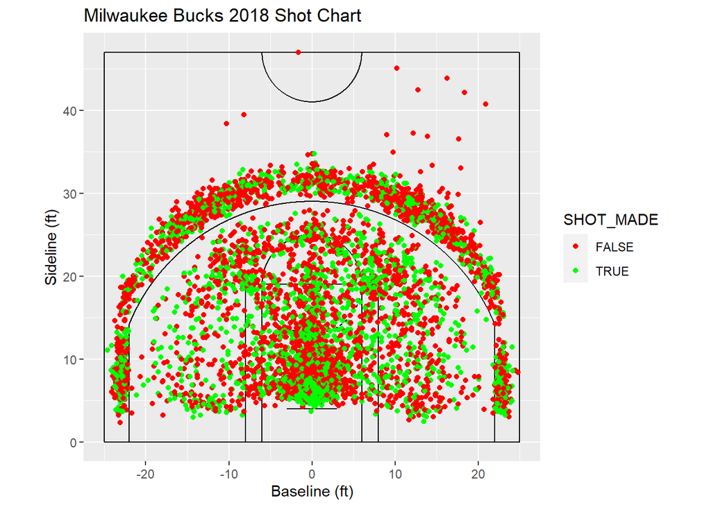

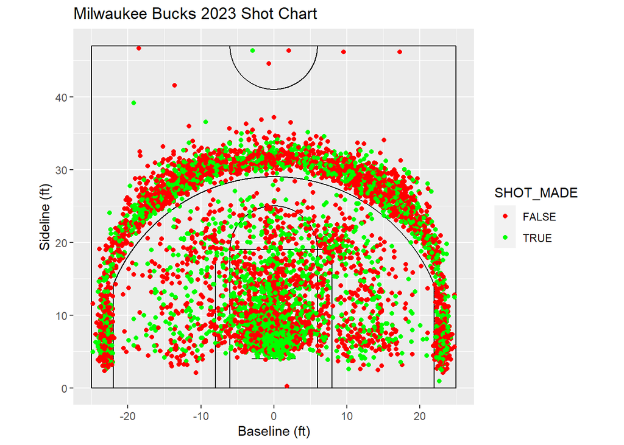

- At first glance, they may look similar but if we dive deeper into them, we can see some interesting changes over 10 years. Let’s look at every shot taken in 2013, 2018, and 2023 for the Milwaukee Bucks. We can see here that there are a lot of points on each graph and it may be difficult to understand what these graphs are showing.
- Green dots are made shots, red dots are missed shots. For this project, we have taken out any shots passed half-court as they are most likely attempts at buzzer-beaters at the end of the quarter and do not accurately portray the Milwaukee Bucks as a whole.

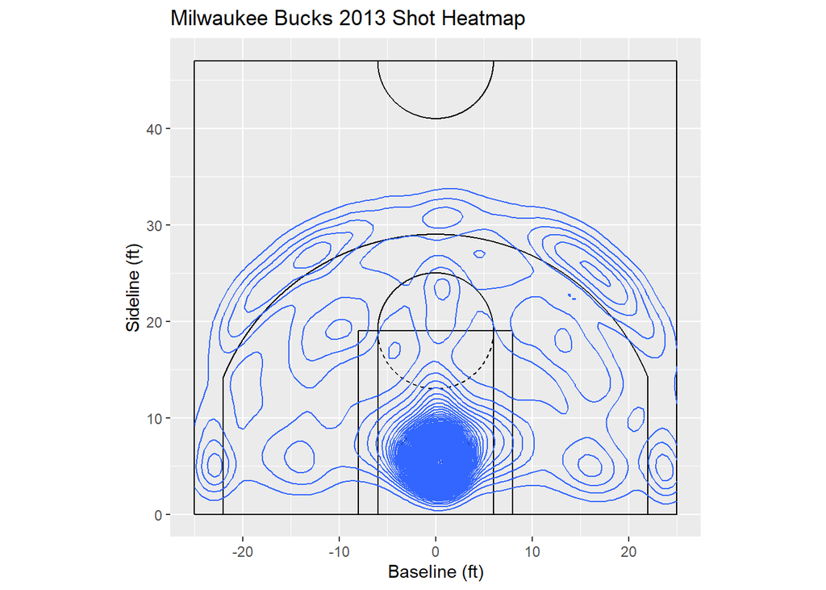

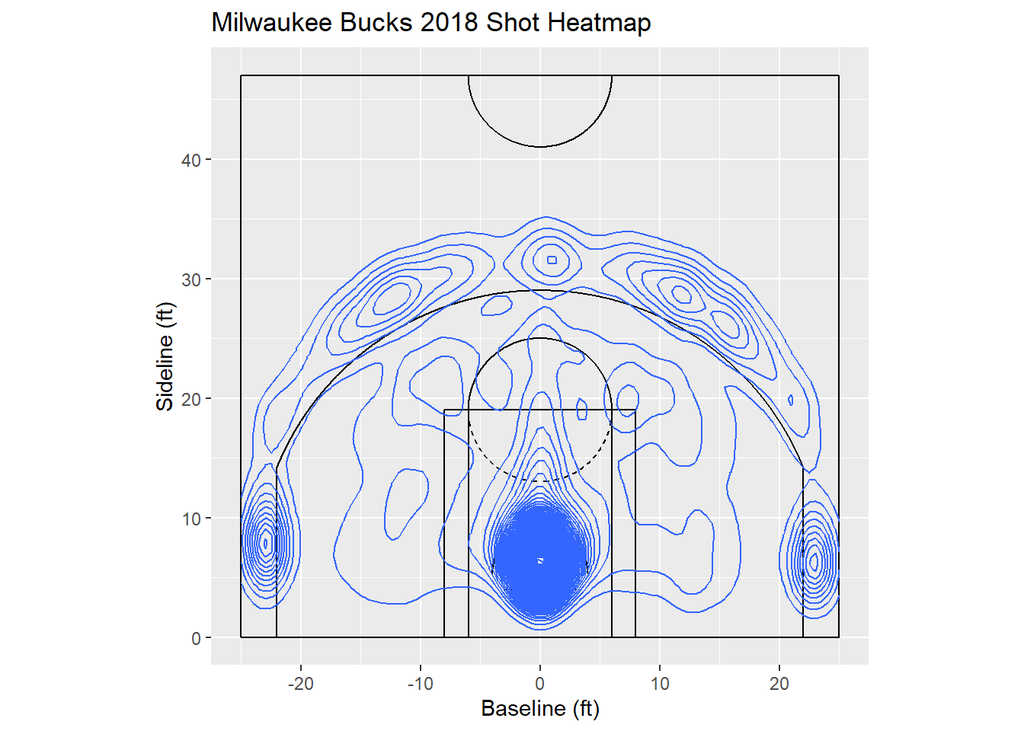

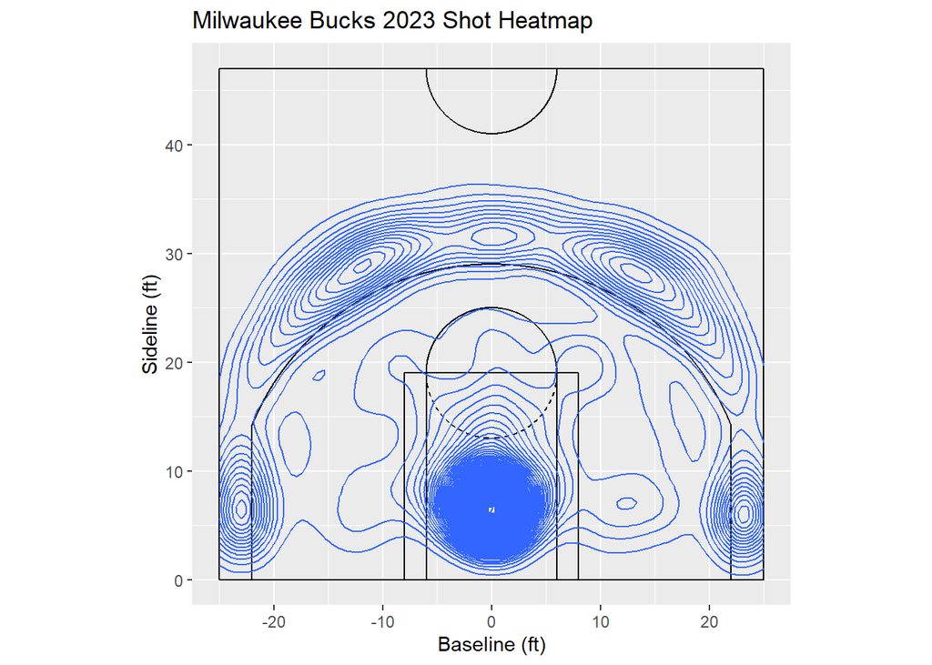

**Interesting things to note:**

- Three-point attempts increase every 5 years.
  - The 2023 team took three-point attempts way beyond the three-point arc as well.
- Shots under the hoop stayed the same.
- The 2013 team took shots all over the court, while the 2018 & 2023 teams had more shots taken in the same areas.
- Team Records:
  - 2013: 15-67
  - 2018: 44-38
  - 2023: 58-24

**Deeper Analysis:**

As we look at shots underneath the hoop, we can see that layups and easy baskets have not changed in terms of shot selection. Whether this was taken for granted or not, we can see that if a player is given a close shot opportunity, he is going to take it.

Combining the third and fourth bullet points, we are going to look closer at the 2013 team. We can see that there are fewer spots on the floor with a higher density of shot attempts. Interpreting this can be difficult, but here is the answer. The 2013 team only had 15 wins, and had one of the worst offenses in the entire league. They were known for having an extremely weak offensive scheme which led to them taking shots wherever they could get them. Comparing this to the 2023 58-win Bucks or even the 2018 Bucks, you can see multiple places on the floor with a higher density of shots. This is due to Head Coach Mike Budenholzer, whose offense had a lot of very well-run plays that led to shots in the same area at times. As the game of basketball has evolved, more three-point shots have been used and are becoming more useful to offenses. Budenholzer’s 2023 Bucks had set plays which led to more open shots, which happened to be more three-point attempts.

**Above and Beyond**

We are now going to look just at Khris Middleton’s shot charts for the 2013, 2018, and 2023 seasons.

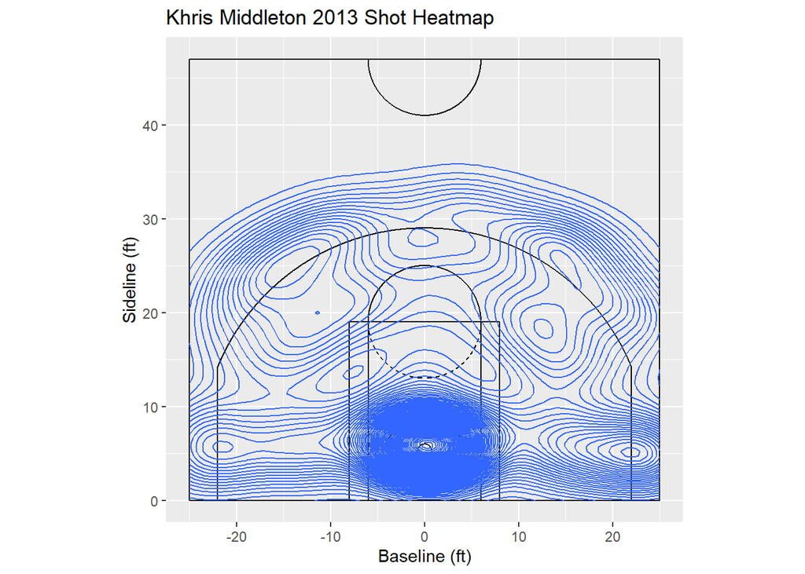

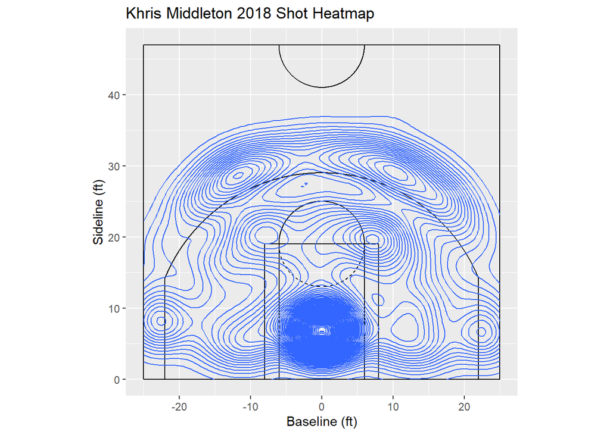

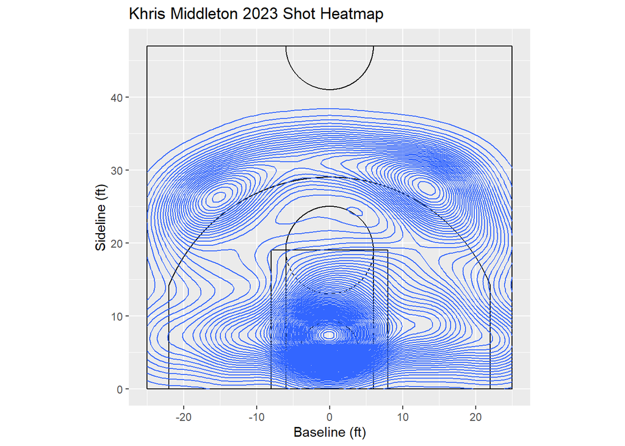

**By Year:**

- 2013: 3.5 3PA/GM
- 2018: 5.0 3PA/GM
- 2023: 4.9 3PA/GM